# Stats 506, Fall 2018, Project

Mimi Tran, mimitran@umich.edu

11/27/2018

Data Analyis: Insurance

The following packages are used in R version of the tutorial.

```r
# libraries--------------------------------------------------------------------
library(faraway)
library(readr)
library(dplyr)
```

# Data Preprocessing and Data Visualization

## Data Preprocessing

```r
# Check if is there any null---------------------------------------------------
is.na(ds0)
```

No missing value, we’re good.

```r
# Recode: sex:femal = 1, male = 0, smoke: yes=1, no=0
ds0$sex[ds0$sex == "male"]="0"
ds0$sex[ds0$sex == "female"]="1"
ds0$smoker[ds0$smoker == "no"]="0"
ds0$smoker[ds0$smoker == "yes"]="1"
```

## Data Visualization

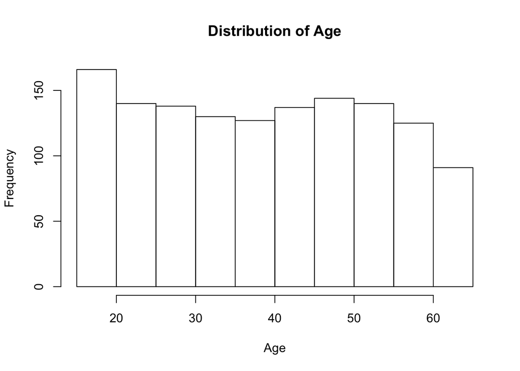

```r
# Examining the distribution of each variables---------------------------------
hist(ds0$age,xlab="Age", main="Distribution of Age")
```

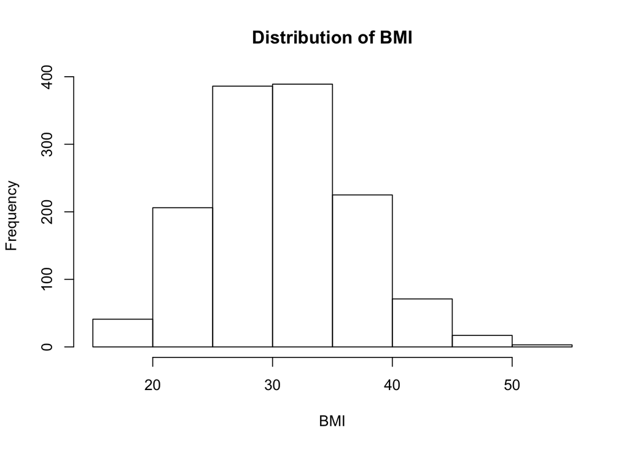

```r
hist(ds0$bmi,xlab="BMI", main="Distribution of BMI")
```

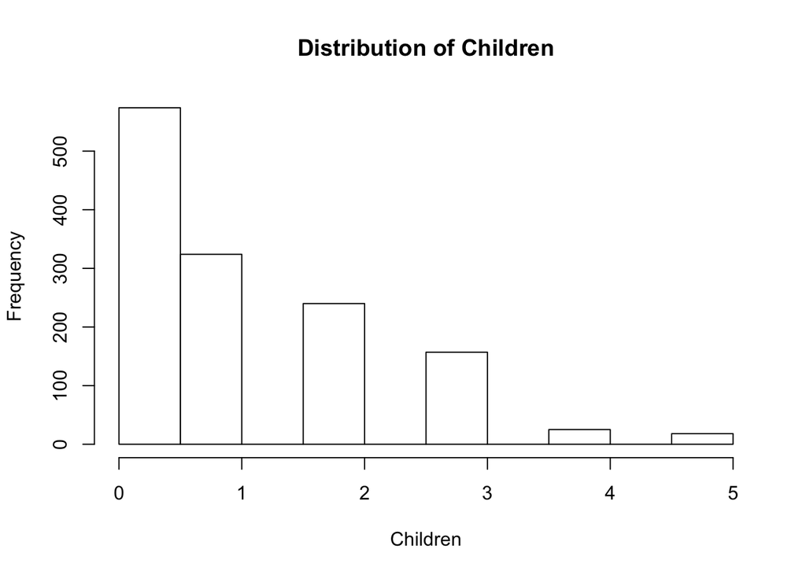

```r
hist(ds0$children,xlab="Children", main="Distribution of Children")
```

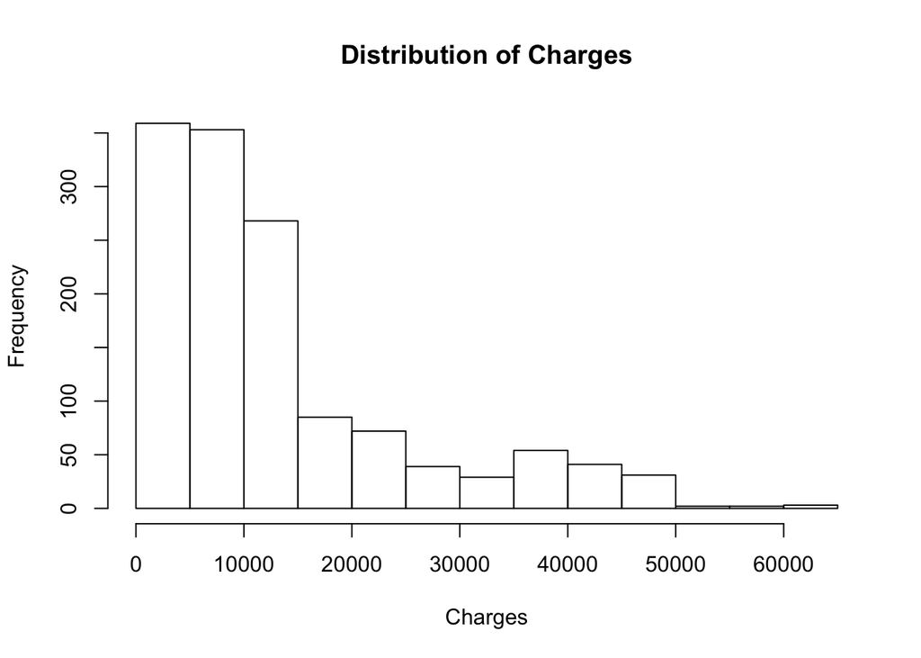

```r
hist(ds0$charges,xlab="Charges", main="Distribution of Charges")
```

```r
# Take log for charge since its heavy tail-------------------------------------
ds0$logcharges <- log(ds0$charges+1)
```

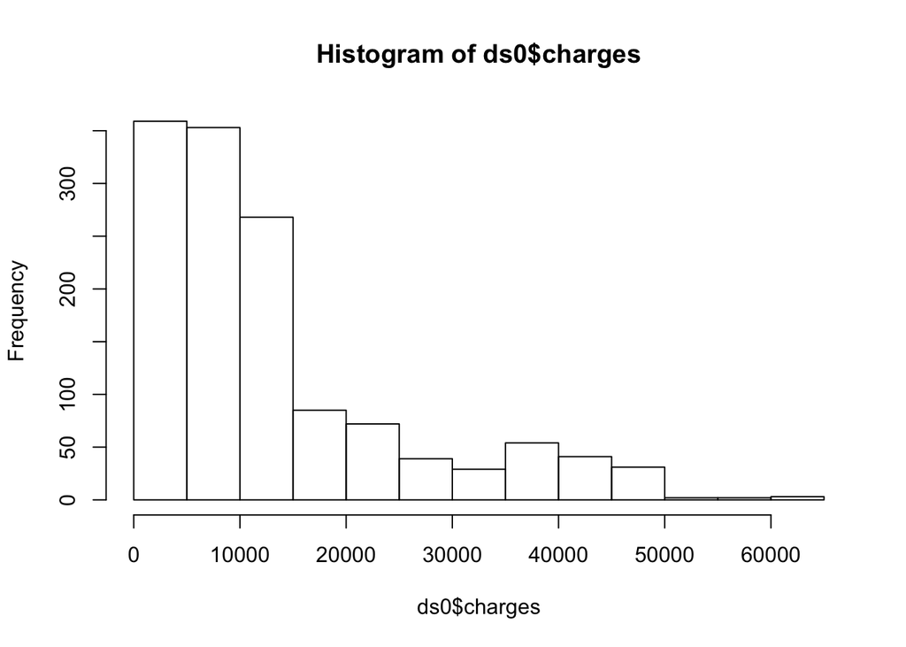

```r
hist(ds0$charges)
```

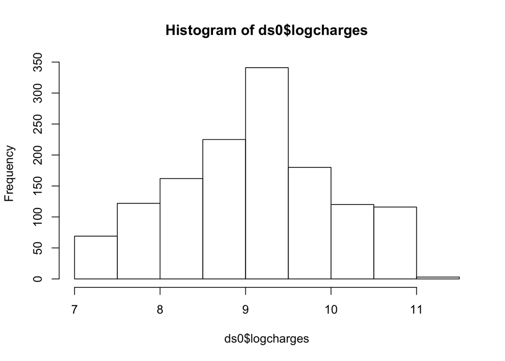

```r
ds0$logcharges <- log(ds0$charges+1)
hist(ds0$logcharges, breaks = 10)
```

# Model Dignostics

Firstly, we define dependent variable y and covariates X. In this analysis, the reponse is *logcharges* and the preditors are *age*, *sex*, *bmi*, *children*, *smoker*, and *region* .

## VIF

```r
# Conduct the first regression!
# Since they're all smaller than 5, even smaller than 2.
fit0 <- lm(logcharges ~age+sex+bmi+children+smoker+as.factor(region), data=ds0)
X <- model.matrix(fit0)[, -1]
round(vif(X),2)
```

```
##                        age                       sex1
##                       1.02                       1.01
##                        bmi                   children
##                       1.11                       1.00
##                    smoker1 as.factor(region)northwest
##                       1.01                       1.52
## as.factor(region)southeast as.factor(region)southwest
##                       1.65                       1.53
```

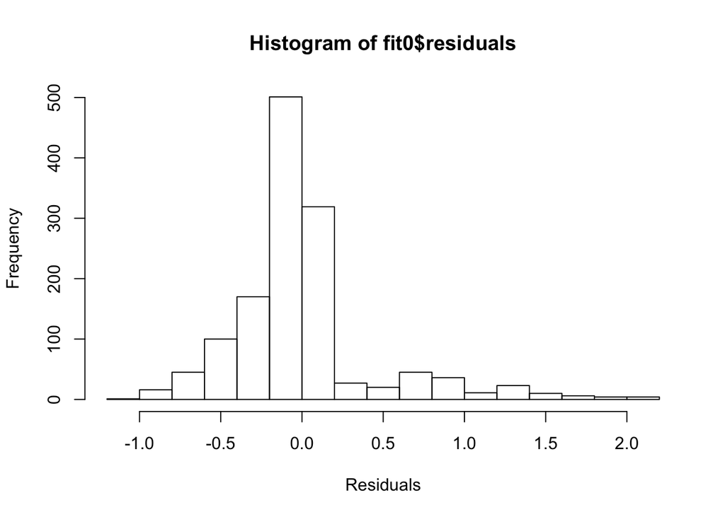

```r
hist(fit0$residuals, xlab="Residuals")
```

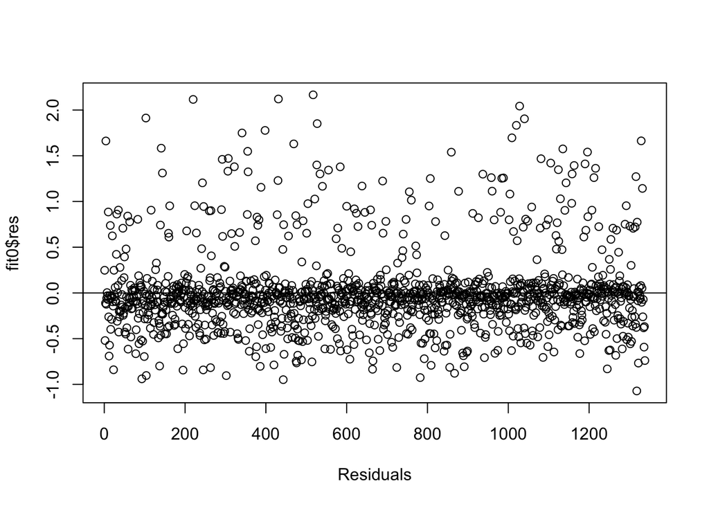

```r
plot(fit0$res, xlab="Residuals")
abline(h=0) # acting like noraml so it's good.
```

## Residual plots

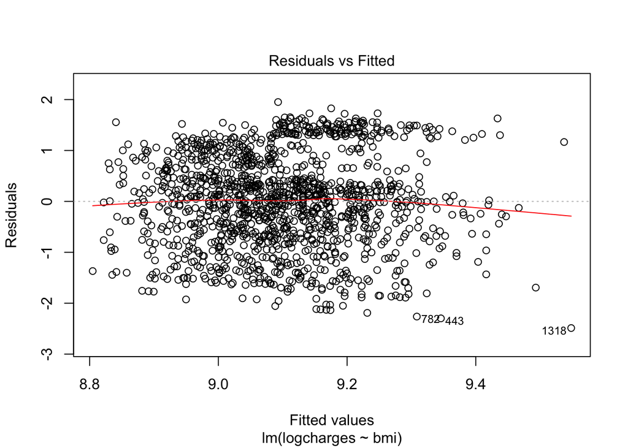

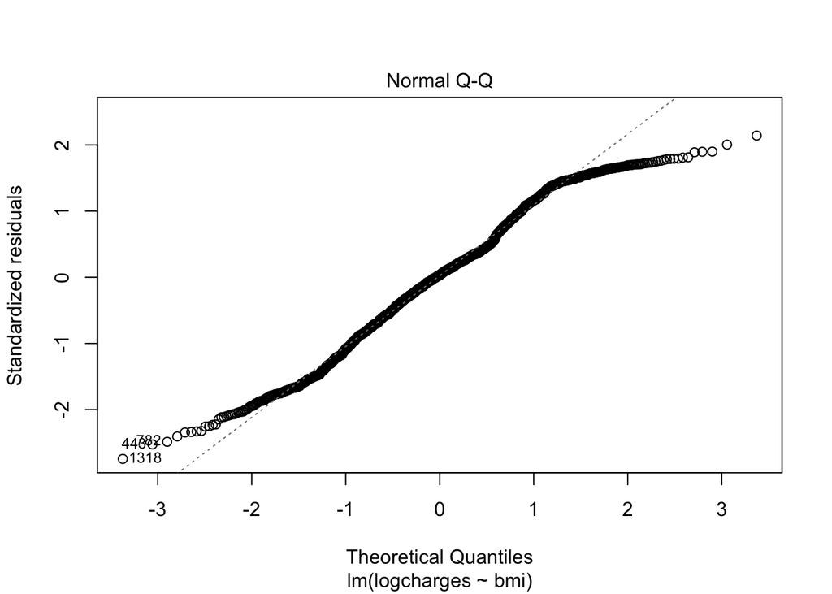

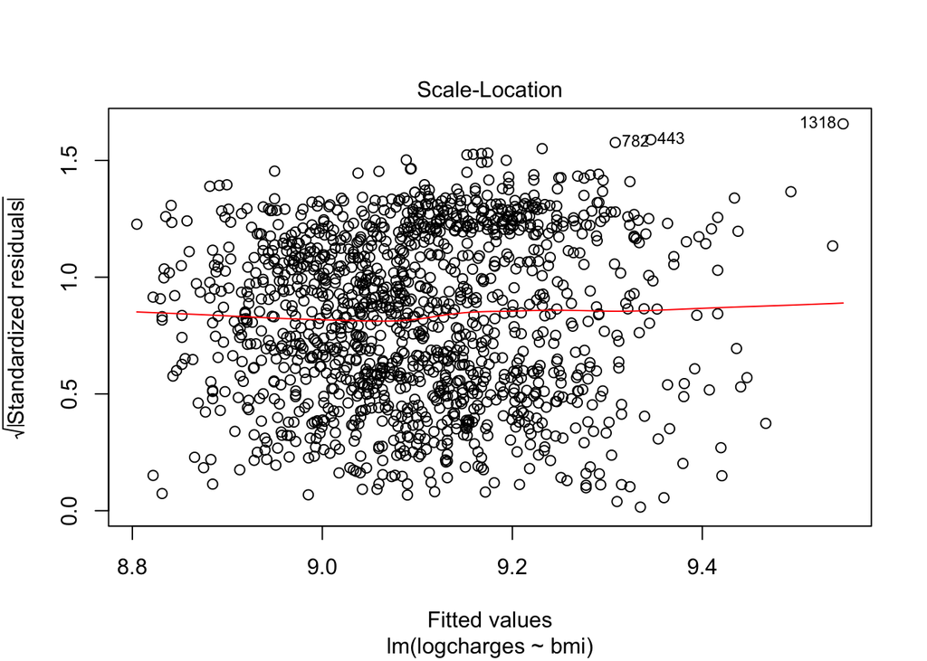

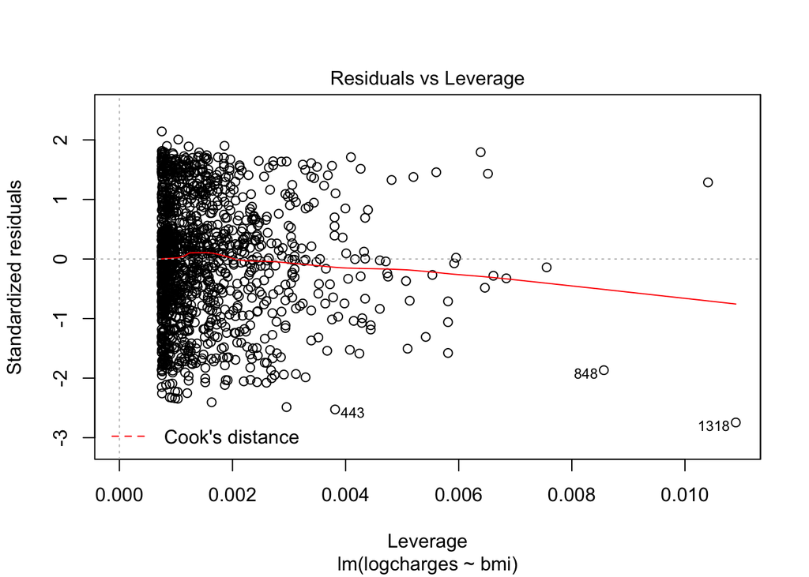

```r
plot(fit)
```

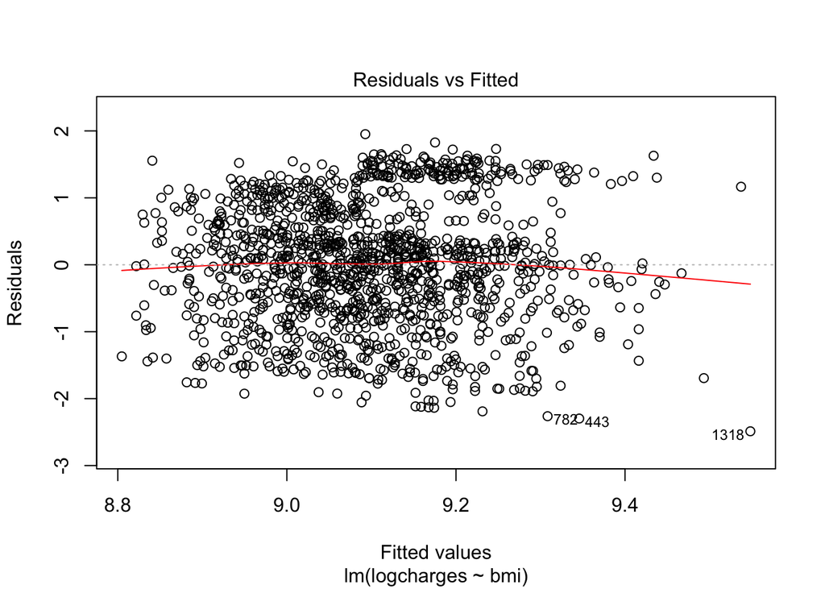

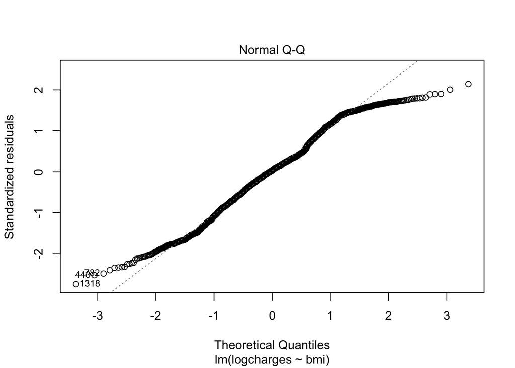

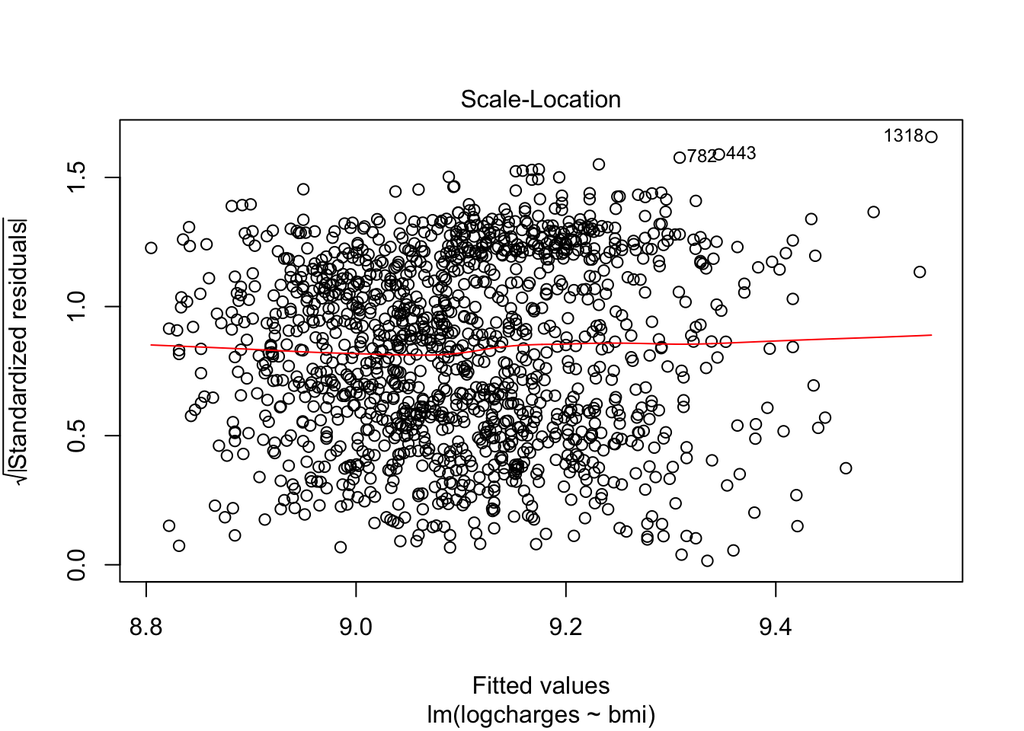

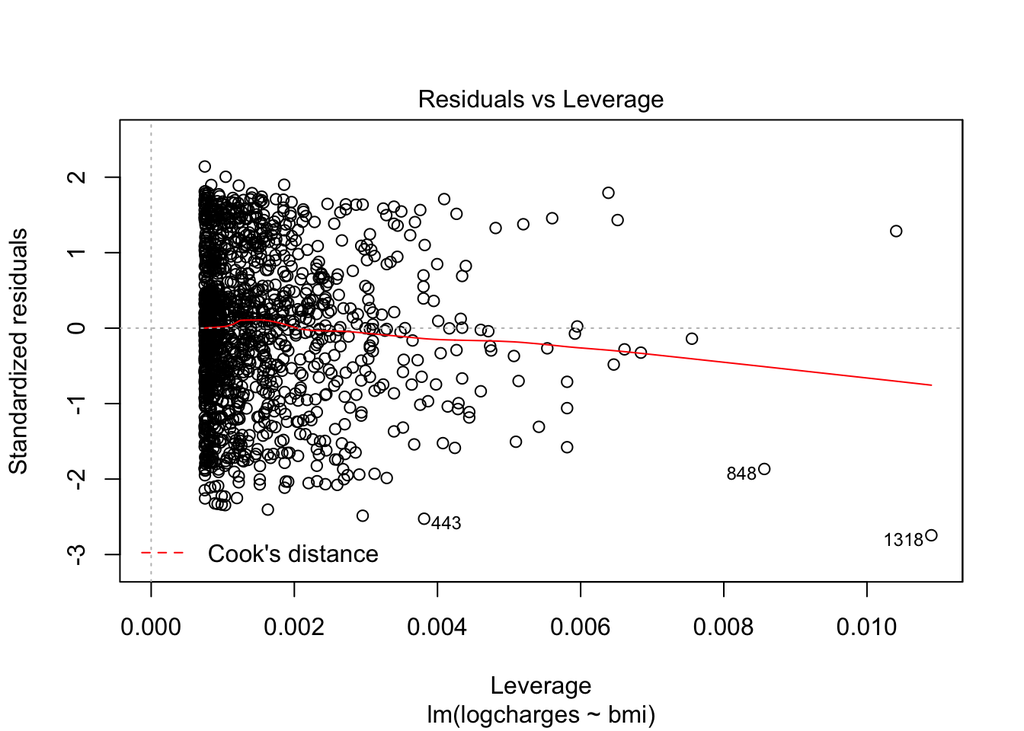

```r
# Partial residual plots-------------------------------------------------------
#Which attempts to show how covariate is related to dependent variable
# if we control for the effects of all other covariates
# partial residual plots look acceptable.
fit <- lm(logcharges~ bmi, data=ds0)
plot(fit)
```

# Model Selection

For this part, we would try different adding variables and try to drop variables that are useless. The primary concern in this case is that we have to add variables so that the residual is relatively indep with y.

### Original model

```r
fit0 <- lm(logcharges ~age+sex+bmi+children+smoker+as.factor(region), data=ds0)
summary(fit0)
```

```
##
## Call:
## lm(formula = logcharges ~ age + sex + bmi + children + smoker +
##     as.factor(region), data = ds0)
##
## Residuals:
##      Min       1Q   Median       3Q      Max
## -1.07141 -0.19836 -0.04914  0.06601  2.16602
##
## Coefficients:
##                              Estimate Std. Error t value Pr(>|t|)
## (Intercept)                 6.9556815  0.0732494  94.959  < 2e-16 ***
## age                         0.0345744  0.0008719  39.655  < 2e-16 ***
## sex1                        0.0753873  0.0243966   3.090 0.002043 **
## bmi                         0.0133740  0.0020956   6.382 2.41e-10 ***
## children                    0.1018259  0.0100976  10.084  < 2e-16 ***
## smoker1                     1.5541456  0.0302739  51.336  < 2e-16 ***
## as.factor(region)northwest -0.0637739  0.0348992  -1.827 0.067867 .
## as.factor(region)southeast -0.1571539  0.0350762  -4.480 8.09e-06 ***
## as.factor(region)southwest -0.1289211  0.0350206  -3.681 0.000241 ***
## ---
## Signif. codes:  0 '***' 0.001 '**' 0.01 '*' 0.05 '.' 0.1 ' ' 1
##
## Residual standard error: 0.4442 on 1329 degrees of freedom
## Multiple R-squared:  0.768,  Adjusted R-squared:  0.7666
## F-statistic: 549.8 on 8 and 1329 DF,  p-value: < 2.2e-16
```

```r
AIC(fit0)
```

```
## [1] 1636.536
```

```r
BIC(fit0)
```

```
## [1] 1688.526
```

### The first try: add interactive covariate smoker*bmi

```r
fit1 <-lm(logcharges ~age+sex+bmi+children+smoker+as.factor(region)+smoker*bmi, data=ds0)
summary(fit1)
```

```
##
## Call:
## lm(formula = logcharges ~ age + sex + bmi + children + smoker +
##     as.factor(region) + smoker * bmi, data = ds0)
##
## Residuals:
##      Min       1Q   Median       3Q      Max
## -0.91486 -0.17764 -0.05144  0.04640  2.22282
##
## Coefficients:
##                              Estimate Std. Error t value Pr(>|t|)
## (Intercept)                 7.2508346  0.0769477  94.231  < 2e-16 ***
## age                         0.0347880  0.0008427  41.280  < 2e-16 ***
## sex1                        0.0870349  0.0236027   3.688 0.000236 ***
## bmi                         0.0034055  0.0022672   1.502 0.133309
## children                    0.1031176  0.0097574  10.568  < 2e-16 ***
## smoker1                     0.1562914  0.1459708   1.071 0.284497
## as.factor(region)northwest -0.0711167  0.0337288  -2.108 0.035176 *
## as.factor(region)southeast -0.1626838  0.0338962  -4.799 1.77e-06 ***
## as.factor(region)southwest -0.1374810  0.0338491  -4.062 5.16e-05 ***
## bmi:smoker1                 0.0455727  0.0046624   9.775  < 2e-16 ***
## ---
## Signif. codes:  0 '***' 0.001 '**' 0.01 '*' 0.05 '.' 0.1 ' ' 1
##
## Residual standard error: 0.4292 on 1328 degrees of freedom
## Multiple R-squared:  0.7835, Adjusted R-squared:  0.7821
## F-statistic: 534.1 on 9 and 1328 DF,  p-value: < 2.2e-16
```

```r
BIC(fit1)
```

```
## [1] 1602.769
```

```r
# which certainly improve the performance of the model
```

### The second try: add an interactive covariate smoker*age

```r
fit2 <-lm(logcharges ~age+sex+bmi+children+smoker+as.factor(region)+smoker*bmi+as.numeric(smoker)*age, data=ds0)
summary(fit2)
```

```
##
## Call:
## lm(formula = logcharges ~ age + sex + bmi + children + smoker +
##     as.factor(region) + smoker * bmi + as.numeric(smoker) * age,
##     data = ds0)
##
## Residuals:
##      Min       1Q   Median       3Q      Max
## -0.65395 -0.15404 -0.06305 -0.01126  2.34914
##
## Coefficients: (1 not defined because of singularities)
##                              Estimate Std. Error t value Pr(>|t|)
## (Intercept)                 7.0475291  0.0701861 100.412  < 2e-16 ***
## age                         0.0415643  0.0008495  48.928  < 2e-16 ***
## sex1                        0.0855867  0.0212384   4.030 5.90e-05 ***
## bmi                         0.0011518  0.0020440   0.563   0.5732
## children                    0.1062970  0.0087818  12.104  < 2e-16 ***
## smoker1                     1.2788788  0.1458651   8.768  < 2e-16 ***
## as.factor(region)northwest -0.0649078  0.0303520  -2.139   0.0327 *
## as.factor(region)southeast -0.1448205  0.0305173  -4.746 2.30e-06 ***
## as.factor(region)southwest -0.1508956  0.0304676  -4.953 8.26e-07 ***
## as.numeric(smoker)                 NA         NA      NA       NA
## bmi:smoker1                 0.0510336  0.0042067  12.132  < 2e-16 ***
## age:as.numeric(smoker)     -0.0333924  0.0018870 -17.696  < 2e-16 ***
## ---
## Signif. codes:  0 '***' 0.001 '**' 0.01 '*' 0.05 '.' 0.1 ' ' 1
##
## Residual standard error: 0.3862 on 1327 degrees of freedom
## Multiple R-squared:  0.8249, Adjusted R-squared:  0.8235
## F-statistic:   625 on 10 and 1327 DF,  p-value: < 2.2e-16
```

```r
BIC(fit2)
```

```
## [1] 1326.493
```

```r
# which increase the performance of the model significantly
```

Since we only have two continuous covariates, we can try to give them an extra power.

```r
 #since we only have two continuous covariates, we can try to give them an extra power, add bmi^1.5.
fit3 <-lm(logcharges ~age+sex+bmi+children+smoker+as.factor(region)+
            smoker*bmi,as.numeric(smoker)*age+bmi^1.5, data=ds0)
summary(fit3)
```

```
##
## Call:
## lm(formula = logcharges ~ age + sex + bmi + children + smoker +
##     as.factor(region) + smoker * bmi, data = ds0, subset = as.numeric(smoker) *
##     age + bmi^1.5)
##
## Residuals:
##      Min       1Q   Median       3Q      Max
## -1.03798 -0.17402 -0.03470  0.05657  2.04224
##
## Coefficients:
##                              Estimate Std. Error t value Pr(>|t|)
## (Intercept)                 7.1763930  0.0720456  99.609  < 2e-16 ***
## age                         0.0375651  0.0007998  46.967  < 2e-16 ***
## sex1                        0.1190553  0.0224451   5.304 1.32e-07 ***
## bmi                        -0.0015026  0.0023231  -0.647   0.5179
## children                    0.1225808  0.0093304  13.138  < 2e-16 ***
## smoker1                     0.0513262  0.1383354   0.371   0.7107
## as.factor(region)northwest  0.0100724  0.0315101   0.320   0.7493
## as.factor(region)southeast -0.0649199  0.0337726  -1.922   0.0548 .
## as.factor(region)southwest -0.1401404  0.0330701  -4.238 2.41e-05 ***
## bmi:smoker1                 0.0495246  0.0045698  10.837  < 2e-16 ***
## ---
## Signif. codes:  0 '***' 0.001 '**' 0.01 '*' 0.05 '.' 0.1 ' ' 1
##
## Residual standard error: 0.4012 on 1328 degrees of freedom
## Multiple R-squared:  0.8077, Adjusted R-squared:  0.8064
## F-statistic: 619.8 on 9 and 1328 DF,  p-value: < 2.2e-16
```

```r
BIC(fit3)
```

```
## [1] 1422.136
```

```r
fit4 <-lm(logcharges ~age+sex+bmi+children+smoker+as.factor(region)+
            smoker*bmi,as.numeric(smoker)*age+bmi^1.5+age^1.5, data=ds0)
summary(fit4)
```

```
##
## Call:
## lm(formula = logcharges ~ age + sex + bmi + children + smoker +
##     as.factor(region) + smoker * bmi, data = ds0, subset = as.numeric(smoker) *
##     age + bmi^1.5 + age^1.5)
##
## Residuals:
##      Min       1Q   Median       3Q      Max
## -0.91636 -0.18144 -0.05810  0.02661  2.13811
##
## Coefficients:
##                              Estimate Std. Error t value Pr(>|t|)
## (Intercept)                 7.2645976  0.0841646  86.314  < 2e-16 ***
## age                         0.0347150  0.0008966  38.720  < 2e-16 ***
## sex1                        0.1085825  0.0249587   4.350 1.46e-05 ***
## bmi                         0.0027220  0.0024320   1.119   0.2632
## children                    0.0792971  0.0107489   7.377 2.84e-13 ***
## smoker1                     0.1785370  0.1539089   1.160   0.2463
## as.factor(region)northwest -0.0821657  0.0375473  -2.188   0.0288 *
## as.factor(region)southeast -0.0423219  0.0348873  -1.213   0.2253
## as.factor(region)southwest -0.0817111  0.0350003  -2.335   0.0197 *
## bmi:smoker1                 0.0419282  0.0048774   8.596  < 2e-16 ***
## ---
## Signif. codes:  0 '***' 0.001 '**' 0.01 '*' 0.05 '.' 0.1 ' ' 1
##
## Residual standard error: 0.4515 on 1328 degrees of freedom
## Multiple R-squared:  0.7465, Adjusted R-squared:  0.7447
## F-statistic: 434.4 on 9 and 1328 DF,  p-value: < 2.2e-16
```

```r
BIC(fit4)
```

```
## [1] 1738.278
```

### The fifth try: What if we take the log away? so we use charges instead of logcharges for the response.

```r
fit5 <-lm(charges ~age+sex+bmi+children+smoker+as.factor(region)+
            smoker*bmi,as.numeric(smoker)*age+bmi^1.5+age^1.5, data=ds0)
summary(fit5)
```

```
##
## Call:
## lm(formula = charges ~ age + sex + bmi + children + smoker +
##     as.factor(region) + smoker * bmi, data = ds0, subset = as.numeric(smoker) *
##     age + bmi^1.5 + age^1.5)
##
## Residuals:
##     Min      1Q  Median      3Q     Max
## -9501.1 -2050.8 -1444.9  -458.8 24540.4
##
## Coefficients:
##                              Estimate Std. Error t value Pr(>|t|)
## (Intercept)                 -1730.677    911.048  -1.900 0.057695 .
## age                           257.277      9.705  26.510  < 2e-16 ***
## sex1                         1003.023    270.168   3.713 0.000214 ***
## bmi                            -3.801     26.325  -0.144 0.885205
## children                      238.749    116.353   2.052 0.040372 *
## smoker1                    -20194.774   1666.003 -12.122  < 2e-16 ***
## as.factor(region)northwest   -921.164    406.435  -2.266 0.023584 *
## as.factor(region)southeast   -335.442    377.641  -0.888 0.374564
## as.factor(region)southwest   -641.983    378.864  -1.694 0.090406 .
## bmi:smoker1                  1422.834     52.796  26.949  < 2e-16 ***
## ---
## Signif. codes:  0 '***' 0.001 '**' 0.01 '*' 0.05 '.' 0.1 ' ' 1
##
## Residual standard error: 4887 on 1328 degrees of freedom
## Multiple R-squared:  0.8247, Adjusted R-squared:  0.8235
## F-statistic: 694.2 on 9 and 1328 DF,  p-value: < 2.2e-16
```

```r
BIC(fit5)
```

```
## [1] 26597.19
```

Now we have added all the possible covariates we can, we can consider drop some of them. As we can see from the summary, it seems that the region parameter is not that important, so I’m only keep *northeast* in *region* column.

```r
new_ds0 <- ds0[which(ds0$region=="northeast"),]
#Recode: sex:femal = 1, male = 0, smoke: yes=1, no=0
new_ds0$sex[new_ds0$sex == "male"]="0"
new_ds0$sex[new_ds0$sex == "female"]="1"
new_ds0$smoker[new_ds0$smoker == "no"]="0"
new_ds0$smoker[new_ds0$smoker == "yes"]="1"
```

```r
# Now fit the model with only region is northeast.
fit6 <- lm(charges ~age+sex+bmi+children+smoker+smoker*bmi+
             as.numeric(smoker)*age+I(bmi^1.5)+I(age^1.5), data=new_ds0)
summary(fit6)
```

```
##
## Call:
## lm(formula = charges ~ age + sex + bmi + children + smoker +
##     smoker * bmi + as.numeric(smoker) * age + I(bmi^1.5) + I(age^1.5),
##     data = new_ds0)
##
## Residuals:
##     Min      1Q  Median      3Q     Max
## -9406.3 -2174.0 -1538.2  -518.7 21804.4
##
## Coefficients: (1 not defined because of singularities)
##                         Estimate Std. Error t value Pr(>|t|)
## (Intercept)             -5132.11    8108.96  -0.633  0.52726
## age                       -99.62     266.41  -0.374  0.70870
## sex1                      792.23     563.31   1.406  0.16060
## bmi                       577.85     748.29   0.772  0.44056
## children                  716.01     247.08   2.898  0.00402 **
## smoker1                -18454.30    3635.64  -5.076 6.62e-07 ***
## as.numeric(smoker)            NA         NA      NA       NA
## I(bmi^1.5)                -58.07      91.07  -0.638  0.52417
## I(age^1.5)                 36.39      28.46   1.279  0.20201
## bmi:smoker1              1444.18     115.75  12.477  < 2e-16 ***
## age:as.numeric(smoker)    -45.95      52.15  -0.881  0.37901
## ---
## Signif. codes:  0 '***' 0.001 '**' 0.01 '*' 0.05 '.' 0.1 ' ' 1
##
## Residual standard error: 4997 on 314 degrees of freedom
## Multiple R-squared:  0.8084, Adjusted R-squared:  0.8029
## F-statistic: 147.2 on 9 and 314 DF,  p-value: < 2.2e-16
```

```r
AIC(fit6)
```

```
## [1] 6450.074
```

```r
BIC(fit6)
```

```
## [1] 6491.662
```

The AIC and BIC actually get smaller.

Similarly smoker*age is not that important either.

```r
fit7 <- lm(charges ~age+sex+bmi+children+smoker+smoker*bmi+region+I(bmi^1.5)+I(age^1.5),data=new_ds0)
summary(fit7)
AIC(fit7)
BIC(fit7)
```

```r
summary(fit7)
```

[output not shown]

```r
AIC(fit7)
```

```
## [1] 26488.94
```

```r
BIC(fit7)
```

```
## [1] 26546.13
```

**Caution: As you may see, the coefficient of smoker1 is negative. Please don’t take the result as smoking is good for your health. Since smoke is also used in smoke:bmi, bmi is large. So the bad influence of smoking has been transferred to the smoke:bmi term.**

## Citation:

1.[link] https://github.com/yihui/knitr-examples/blob/master/023-engine-python.Rmd

2.[link] https://www.kaggle.com/sudhirnl7/linear-regrssion-tutorial